# Binary Logistic Regression

- Show All Code
- Hide All Code
- View Source

A worked example using couples data

Author

Graduate Statistics — Demonstration

## Purpose

This report demonstrates a complete binary logistic regression workflow. We will use the couples dataset from class.

Our objectives are to:

1. **Specify and estimate** several plausible competing binary logistic regression models using `glmmTMB`.
2. **Compare nested models** using likelihood-ratio tests (χ²).
3. **Evaluate overall model fit** using AIC and BIC.
4. **Examine model diagnostics** and assess assumptions relevant to binary logistic regression.
5. **Select and interpret** a preferred model, including transforming log-odds coefficients into odds ratios.
6. **Report results reproducibly** using tables, figures, and Quarto.

## 1. Load packages and prepare the data

Install any missing packages **once in the R Console**:

```r
install.packages(c(
  "glmmTB", "dplyr", "tidyr", "ggplot2",
  "broom.mixed", "performance", "gt",
  "DHARMa", "ggeffects"))
```

The following code belongs in the Quarto document.

```r
library(glmmTMB)
library(dplyr)
library(tidyr)
library(ggplot2)
library(broom.mixed)
library(performance)
library(gt)
library(readr)
library(DHARMa)
library(ggeffects)

couples <- read_csv("data/couples.csv")

n <- nrow(couples)
```

The dataset contains information about couples’ relationship status (`stayed`), relationship satisfaction scores (`satisfaction`), attachment avoidance scores (`avoidance`), and cohabitation status (`cohabiting`).

### Research Question and Predictions

How are `avoidance`, `satisfaction`, and `cohabiting` associated with whether couples `stayed` together?

We expect:

- Couples with **higher relationship satisfaction scores** are more likely to stay together.
- Couples with **lower attachment avoidance scores** are more likely to stay together.
- Couples **who cohabit (live together)** are more likely to stay together.

These are predictions about associations, not causal effects.

## 2. Explore the data

It is important to familiarize yourself with the data, including the cell counts for each of your categorical variables.

```r
descriptives <- couples |>
  summarise(
    across(
      c(avoidance, satisfaction),
      list(mean = mean, sd = sd, min = min, max = max)
    )
  ) |>
  pivot_longer(
    everything(),
    names_to = c("variable", ".value"),
    names_sep = "_"
  )

descriptives |>
  gt() |>
  fmt_number(columns = where(is.numeric), decimals = 2)
```

| variable | mean | sd | min | max |
| --- | --- | --- | --- | --- |
| avoidance | 3.04 | 1.07 | 1.00 | 7.00 |
| satisfaction | 4.67 | 1.16 | 1.51 | 7.00 |

### Stayed together

```r
couples |>
  count(status) |>
  gt()
```

| status | n |
| --- | --- |
| Dissolved | 157 |
| Together | 163 |

### Cohabiting

```r
couples |>
  count(cohabiting) |>
  gt()
```

| cohabiting | n |
| --- | --- |
| No | 168 |
| Yes | 152 |

## 3. Specify and estimate competing models

We will fit an intercept-only model and three increasingly complex substantive models.

| Model | Formula | Research rationale |
| --- | --- | --- |
| mod0: Null | `stayed ~ 1` | Baseline model |
| mod1: Satisfaction | `stayed ~ satisfaction` | Staying together varies with relationship satisfaction |
| mod2: Satisfaction + Avoidance | `stayed ~ satisfaction + avoidance` | Avoidant attachment explains additional variation |
| mod3: Satisfaction + Avoidance + Cohabiting | `stayed ~ satisfactoin + avoidance + cohabiting` | Cohabiting explains additional variation |

The models are **nested**: each successive model contains all predictors from the preceding model, plus one or more additional predictors.

```r
mod0 <- glmmTMB(stayed ~ 1,data = couples,
  family = binomial(link = "logit"))

mod1 <- glmmTMB(
  stayed ~ satisfaction,
  data = couples,
  family = binomial(link = "logit"))

mod2 <- glmmTMB(
  stayed ~ satisfaction + avoidance,
  data = couples,
  family = binomial(link = "logit"))

mod3 <- glmmTMB(
  stayed ~ satisfaction + avoidance + cohabiting,
  data = couples,
  family = binomial(link = "logit"))
```

After executing the model-fitting code, explore the results in the **R Console**:

```r
summary(mod0)
summary(mod1)
summary(mod2)
summary(mod3)

confint(mod3)
```

## 4. Nested Model Comparisons

We will evaluate the models. Our main performance metrics are:

- **AIC:** Evaluates model fit while penalizing model complexity. Lower values indicate a preferred balance between fit and complexity.
- **BIC:** Similar to AIC, but applies a stronger penalty for model complexity. Lower values are preferred.
- **Likelihood-ratio test (χ²):** Tests whether adding predictors significantly improves model fit relative to the preceding model. A statistically significant p-value (p < .05) indicates that the additional predictors improve model fit.

### 4.1. Compare the models

Because our models are nested and estimated using the same observations, we can compare all four models in a single `anova()` call.

```r
tests <- anova(mod0, mod1, mod2, mod3)

tests
```

```
Data: couples
Models:
mod0: stayed ~ 1, zi=~0, disp=~1
mod1: stayed ~ satisfaction, zi=~0, disp=~1
mod2: stayed ~ satisfaction + avoidance, zi=~0, disp=~1
mod3: stayed ~ satisfaction + avoidance + cohabiting, zi=~0, disp=~1
     Df    AIC    BIC  logLik deviance   Chisq Chi Df Pr(>Chisq)
mod0  1 445.50 449.27 -221.75   443.50
mod1  2 402.98 410.52 -199.49   398.98 44.5174      1  2.521e-11 ***
mod2  3 395.36 406.66 -194.68   389.36  9.6276      1   0.001917 **
mod3  4 391.72 406.79 -191.86   383.72  5.6382      1   0.017573 *
---
Signif. codes:  0 '***' 0.001 '**' 0.01 '*' 0.05 '.' 0.1 ' ' 1
```

Each row represents a model. We can retain and rename the statistics relevant to our comparison table.

```r
tests <- tests |>
  select(Chisq, `Chi Df`, `Pr(>Chisq)`) |>
  rename(
    Nested.df = `Chi Df`,
    Nested.Chisq.stat = Chisq,
    Nested.p.value = `Pr(>Chisq)`)
```

### 4.2. Extract overall model performance

The `glance()` function from the `broom.mixed` package returns a one-row data frame containing model-level statistics.

We can apply it to each fitted model.

```r
glance0 <- broom.mixed::glance(mod0)
glance1 <- broom.mixed::glance(mod1)
glance2 <- broom.mixed::glance(mod2)
glance3 <- broom.mixed::glance(mod3)
```

We can then combine these results using `rbind()`.

```r
mods <- c(
  "mod0: Null",
  "mod1: Satisfaction",
  "mod2: + Avoidance",
  "mod3: + Cohabiting")

glances <- rbind(
  glance0,
  glance1,
  glance2,
  glance3)
```

### 4.3. Combine nested tests and model performance

Because the rows in `glances` and `tests` represent the same models in the same order, we can combine them using `cbind()`.

```r
comparison_table <- cbind(
  Model = mods,
  glances,
  tests)
```

### 4.4. Display the combined model comparison table

```r
comparison_table |>
  select(
    Model,
    AIC,
    BIC,
    logLik,
    deviance,
    df.residual,
    Nested.df,
    Nested.Chisq.stat,
    Nested.p.value
  ) |>
  gt() |>
  cols_label(
    Model = "Model",
    AIC = "AIC",
    BIC = "BIC",
    logLik = "Log-likelihood",
    deviance = "Deviance",
    df.residual = "Residual.df",
    Nested.df = "Nested df",
    Nested.Chisq.stat = "Nested χ²",
    Nested.p.value = "Nested p"
  ) |>
  fmt_number(
    columns = c(
      AIC,
      BIC,
      logLik,
      deviance,
      Nested.Chisq.stat
    ),
    decimals = 3
  ) |>
  fmt(
    columns = Nested.p.value,
    fns = function(x) {
      ifelse(
        is.na(x),
        "—",
        ifelse(x < .001, "< .001", sprintf("%.3f", x))
      )
    }
  ) |>
  sub_missing(
    columns = c(Nested.df, Nested.Chisq.stat),
    missing_text = "—"
  )
```

| Model | AIC | BIC | Log-likelihood | Deviance | Residual.df | Nested df | Nested χ² | Nested p |
| --- | --- | --- | --- | --- | --- | --- | --- | --- |
| mod0: Null | 445.502 | 449.270 | −221.751 | 443.502 | 319 | — | — | — |
| mod1: Satisfaction | 402.984 | 410.521 | −199.492 | 398.984 | 318 | 1 | 44.517 | < .001 |
| mod2: + Avoidance | 395.357 | 406.662 | −194.678 | 389.357 | 317 | 1 | 9.628 | 0.002 |
| mod3: + Cohabiting | 391.718 | 406.792 | −191.859 | 383.718 | 316 | 1 | 5.638 | 0.018 |

### 4.5. Interpreting the combined table

Each row represents one fitted binary logistic regression model.

When comparing models, we generally look for **lower AIC and BIC values** and whether the **likelihood-ratio test** **indicates a statistically significant improvement** in model fit.

For example, the mod2 row tells us how well mod2 fits the data relative to mod1, considering both model fit and complexity (AIC, BIC). The likelihood-ratio test is significant, telling us that adding avoidance as a predictor significantly improves model fit beyond satisfaction.

The mod3 comparison tests whether adding cohabitation significantly improves model fit after accounting for satisfaction and avoidance. For mod3, the likelihood-ratio test is significant, AIC is lower, however, BIC slightly increases. Given how minimally BIC increases, **mod3 is our preferred model**.

Remember: The mod0 row has no incremental comparison because it serves as the baseline.

### Additional performance comparison

The `performance` package also provides a convenient way to compare fitted models.

```r
performance_comparison <- compare_performance(
  mod0,
  mod1,
  mod2,
  mod3,
  rank = TRUE)
```

In the Console, inspect:

```r
performance_comparison
plot(performance_comparison)
```

These functions may include additional metrics, such as Tjur’s R2, which we will not focus on here.

## 5. Select a provisional model

Model selection requires considering both statistical evidence and model complexity.

In particular, we should consider:

- Nested-model χ²-tests.
- AIC.
- BIC.
- Model complexity.
- Diagnostic findings.
- Substantive interpretability.

For this demonstration, we will use the **likelihood-ratio test** as an initial selection criterion. We can see that the likelihood ratio test is still significant for our most complex model, mod3. Therefore we will select our model by `filter`ing by `Nested.p.value` and using `slice_tail()` to extract the last row in our comparison table.

```r
selected_row <- comparison_table |>
  filter(Nested.p.value < .05) |>
  slice_tail(n = 1)

#creating an object with our selected model's name for dynamic reporting
selected_name <- selected_row$Model

#case matching for dynamic reporting
selected_model <- switch(
  selected_name,
  "mod0: Null" = mod0,
  "mod1: Satisfaction" = mod1,
  "mod2: + Avoidance" = mod2,
  "mod3: + Cohabiting" = mod3)
```

The provisionally selected model is **mod3: + Cohabiting**.

Its performance is:

- AIC = **391.718**
- BIC = **406.792**

We will now examine whether the selected model has important diagnostic problems.

## 6. Evaluate binary logistic regression diagnostics

Binary logistic regression diagnostics help identify potential violations of model assumptions and unusual observations.

Here, we will examine:

1. **Linearity on the log-odds scale**, not on the probability scale
2. **No catastrophic collinearity**
3. **No complete separation**
4. **No influential outliers**
5. **Events per predictor**

### 6.1 Linearity on the logit scale

```r
set.seed(9041)
res_mod3 <- simulateResiduals(mod3, n = 500, plot = FALSE)
```

#### The default DHARMa plot

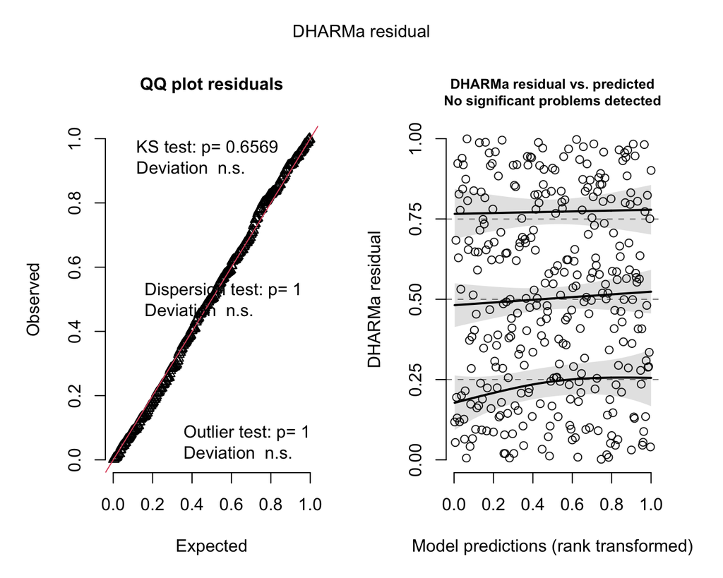

When interpreting these plots, consider:

**Q–Q plot**

- Do the residuals deviate substantially from a uniform distribution on the log-odds scale?

**DHARMa residuals vs. predicted plot**

- Does residual variability change across fitted values on the log-odds scale?

- Are there observations with unusually high leverage or influence?

### 6.2 Collinearity

```
# Check for Multicollinearity

Low Correlation

         Term  VIF   VIF 95% CI adj. VIF Tolerance Tolerance 95% CI
 satisfaction 1.09 [1.02, 1.37]     1.05      0.92     [0.73, 0.98]
    avoidance 1.09 [1.02, 1.37]     1.05      0.92     [0.73, 0.98]
   cohabiting 1.05 [1.00, 1.59]     1.02      0.96     [0.63, 1.00]
```

### 6.3 Complete separation

We should not have predictor(s) that **perfectly** predict the outcome variable. Therefore, it is important to check for symptoms for this in your preferred model. The main symptom are:

- Very large coefficients and standard errors
- `glmmTMB`warnings about convergence
- Fitted probabilities of essentially 0 or 1 for some groups

### 6.4 Influence

Cook’s distance is not implemented for `glmmTMB`, so use the `DHARMa` again to check for outliers.

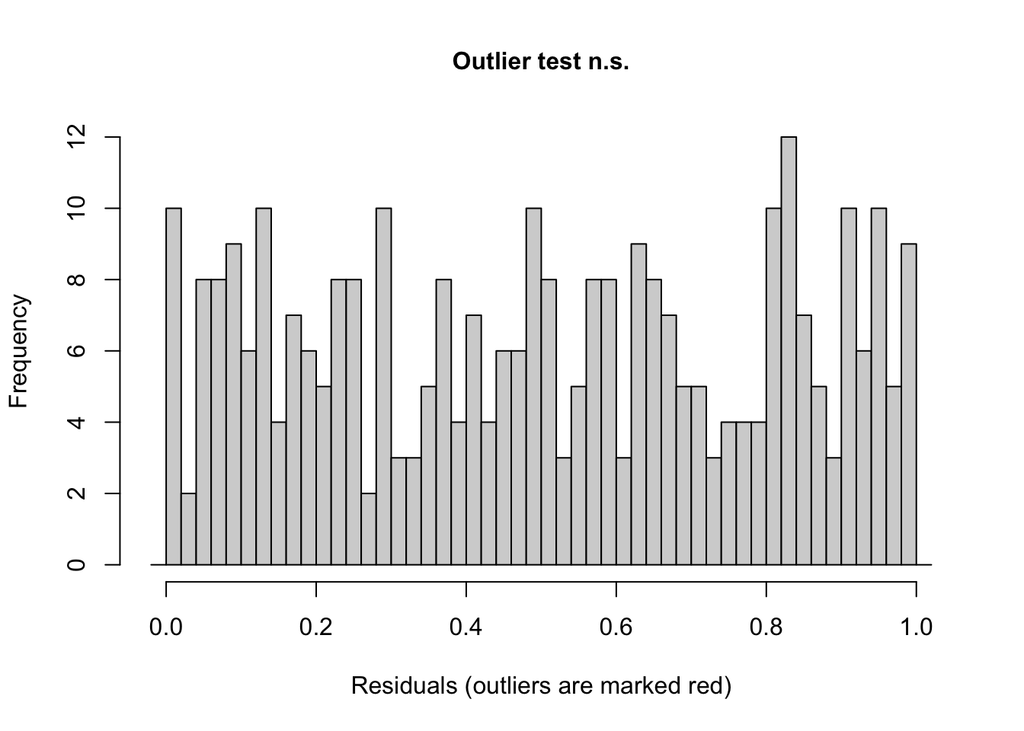

```
    DHARMa bootstrapped outlier test

data:  res_mod3
outliers at both margin(s) = 0, observations = 320, p-value = 1
alternative hypothesis: two.sided
 percent confidence interval:
 0 0
sample estimates:
outlier frequency (expected: 0 )
                               0
```

```r
testOutliers(res_mod3)
```

### 6.5 Events per predictor

A rough working rule: at least **10 events (and 10 non-events) per coefficient**.

Here we have 163 together-couples and 157 dissolved-couples, with 3 coefficients in `mod3`.

These diagnostics should inform your final model selection. A model with slightly better fit statistics may not be preferable if its assumptions are seriously compromised. For the purposes of this worked example, we retain the provisionally selected model for the reporting demonstration.

## 7. Report the selected model

### 7.1. Extract binary logistic regression coefficients

Note that we need to use `tidy::broom.mixed` to extract coefficient-level results from a fitted binary logistic regression model.

```r
coefficient_results <- broom.mixed::tidy(
  selected_model,
  effects = "fixed",
  component = "cond",
  conf.int = TRUE,
  conf.level = 0.95)
```

The resulting data frame contains:

- Coefficient estimates.
- Standard errors.
- Test statistics.
- p-values.
- Confidence interval limits.

### 7.2. Create a binary logistic regression coefficient table

```r
coefficient_results |>
  select(
    term,
    estimate,
    std.error,
    conf.low,
    conf.high,
    p.value
  ) |>
  gt() |>
  cols_label(
    term = "Predictor",
    estimate = "Estimate",
    std.error = "SE",
    conf.low = "95% CI lower",
    conf.high = "95% CI upper",
    p.value = "p"
  ) |>
  fmt_number(
    columns = c(
      estimate,
      std.error,
      conf.low,
      conf.high
    ),
    decimals = 3
  ) |>
  fmt(
    columns = p.value,
    fns = function(x) {
      ifelse(
        x < .001,
        "< .001",
        sprintf("%.3f", x)
      )
    }
  )
```

| Predictor | Estimate | SE | 95% CI lower | 95% CI upper | p |
| --- | --- | --- | --- | --- | --- |
| (Intercept) | −2.769 | 0.623 | −3.991 | −1.547 | < .001 |
| satisfaction | 0.802 | 0.122 | 0.562 | 1.041 | < .001 |
| avoidance | −0.400 | 0.121 | −0.638 | −0.163 | < .001 |
| cohabitingYes | 0.592 | 0.252 | 0.098 | 1.085 | 0.019 |

### 7.3. Report overall model performance

```r
selected_row |>
  select(
    Model,
    AIC,
    BIC,
    logLik,
    deviance,
    df.residual,
    Nested.df,
    Nested.Chisq.stat,
    Nested.p.value
  ) |>
  gt() |>
  cols_label(
    Model = "Model",
    AIC = "AIC",
    BIC = "BIC",
    logLik = "Log-likelihood",
    deviance = "Deviance",
    df.residual = "Residual df",
    Nested.df = "Nested df",
    Nested.Chisq.stat = "Nested χ²",
    Nested.p.value = "Nested p"
  ) |>
  fmt_number(
    columns = where(is.numeric),
    decimals = 2
  )
```

| Model | AIC | BIC | Log-likelihood | Deviance | Residual df | Nested df | Nested χ² | Nested p |
| --- | --- | --- | --- | --- | --- | --- | --- | --- |
| mod3: + Cohabiting | 391.72 | 406.79 | −191.86 | 383.72 | 316.00 | 1.00 | 5.64 | 0.02 |

## 8. Interpret the results

### 8.1. Coefficients are on the log-odds scale

```r
fixef(mod3)
```

```
Conditional model:
  (Intercept)   satisfaction      avoidance  cohabitingYes
      -2.7690         0.8019        -0.4001         0.5916
```

The coefficients represent changes in the log-odds of staying together at 12 months, holding the other predictors constant.

For a one-point increase in satisfaction, holding avoidance and cohabiting status constant, the **log-odds** of staying together increase by 0.8.

For a one-point increase in avoidance, holding satisfaction and cohabiting status constant, the **log-odds** of staying together decrease by 0.4.

The coefficient for `cohabitingYes` represents the **log-odds difference** between cohabiting and non-cohabiting couples, holding satisfaction and avoidance constant. Recall that not cohabiting is our reference group, therefore the log-odds of staying together increase by 0.59 when couples live together compared to when they do not , holding satisfaction and avoidance constant.

### 8.2 Transform log-odds into odds ratios

Exponentiating the coefficients transforms them from log-odds into odds ratios.

```r
exp(fixef(mod3)$cond)
```

```
  (Intercept)  satisfaction     avoidance cohabitingYes
   0.06272427    2.22968481    0.67022271    1.80683201
```

We can also exponentiate the confidence intervals to obtain 95% confidence intervals for the odds ratios.

```r
or_ci <- exp(confint(mod3, parm = "beta_"))
or_ci
```

```
                   2.5 %    97.5 %   Estimate
(Intercept)   0.01848829 0.2128014 0.06272427
satisfaction  1.75456494 2.8334627 2.22968481
avoidance     0.52859712 0.8497937 0.67022271
cohabitingYes 1.10304976 2.9596506 1.80683201
```

### Interpreting satisfaction

Holding avoidance and cohabiting status constant, a one-point increase in satisfaction is associated with 2.23 times the odds of staying together at 12 months, 95% CI [1.75, 2.83].

### Interpreting avoidance

Holding satisfaction and cohabiting status constant, a one-point increase in avoidance is associated with 0.67 times the odds of staying together at 12 months, 95% CI [0.53, 0.85].

### Interpreting cohabiting

Holding satisfaction and avoidance constant, cohabiting couples have 1.81 times the odds of staying together at 12 months compared to non-cohabiting couples, 95% CI [1.1, 2.96].

### 8.3 Visualizing results as predicted probabilities

We can visualize the associations between our predictors and outcome variable using **predicted probabilities**, which can be calculated using `ggeffects::ggpredict()` and plotted using `ggplot2`.

#### Satisfaction

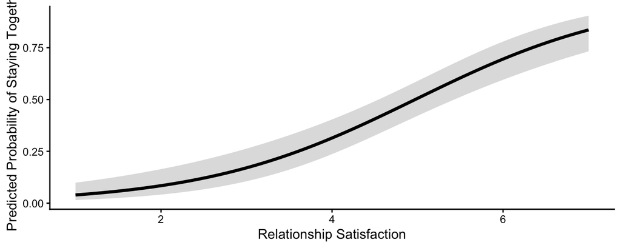

```r
pred_sat <- ggpredict(mod3, terms = "satisfaction [1:7 by=0.05]")

ggplot(pred_sat, aes(x, predicted)) +
  geom_ribbon(aes(ymin = conf.low, ymax = conf.high), alpha = 0.18) +
  geom_line(linewidth = 1.2) +
  labs(
    x = "Relationship Satisfaction",
    y = "Predicted Probability of Staying Together"
  ) +
  theme_classic()
```

#### Avoidance

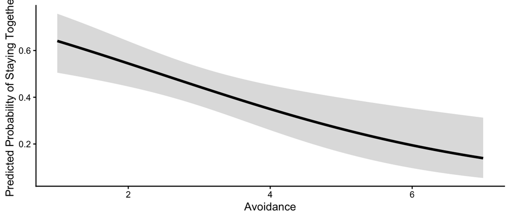

```r
pred_pclass <- ggpredict(mod3, terms = "avoidance [1:7 by=0.05]")

ggplot(pred_pclass, aes(x, predicted)) +
  geom_ribbon(aes(ymin = conf.low, ymax = conf.high), alpha = 0.18) +
  geom_line(linewidth = 1.2) +
  labs(
    x = "Avoidance",
    y = "Predicted Probability of Staying Together"
  ) +
  theme_classic()
```

### Results paragraph

> We fit a binomial GLM with a logit link predicting 12-month relationship status from satisfaction, attachment avoidance, and cohabiting status. Higher satisfaction was associated with higher odds of remaining together, OR = 2.23, 95% CI [1.75, 2.83]. Higher attachment avoidance was associated with lower odds of remaining together, OR = 0.67, 95% CI [0.53, 0.85]. Cohabiting couples had higher odds of remaining together compared to non-cohabiting couples, OR = 1.81, 95% CI [1.1, 2.96].

### Substantive conclusions

This analysis illustrates how relationship dissolution can be investigated using several competing binary logistic regression models.

The model-comparison process allows us to evaluate whether additional predictors explain meaningful variation beyond simpler models.

The final model provides estimates of the odds of a couple staying together or dissolving.